# Communicate Data Findings - Pisa 2012 Results Data

## by Gurps Rai

#### ‘What is important for citizens to know and be able to do?’

> **This is the underlying question that the Programme for International Students Assessment (Pisa), tries to answer.**

Pisa attempts to understand the range and scope of keys skills that have been acquired by 15 year-old-students, across 65 countries (34 OECD member countries, and 31 partner countries), that are deemed crucial for full participation in modern societies. The Pisa assessment focuses on reading, mathematics, science, and problem solving, along with a whole host of other matrices, that are deemed to have an effect on educational achievement.

The publication of the Pisa report allows policy makers around the world to understand key skills and knowledge that students (at age 15) have acquired both in their own countries, and other countries too, allowing them to learn from policies and practices used elsewhere.

## Preliminary Wrangling

```python
# import all packages and set plots to be embedded inline
import numpy as np
import pandas as pd
import matplotlib.pyplot as plt
import seaborn as sb

%matplotlib inline
```

```python
# load dataset into pandas dataframe, using latin-1 encoding
df = pd.read_csv('pisa2012.csv',sep=',', encoding='latin-1',error_bad_lines=False, index_col=False, dtype='unicode')
```

```python
# Overview of dataset shape
df.shape
```

```
(485490, 636)
```

```python
# Display all 636 columns of DF
pd.options.display.max_columns = None
df.head(20)
```

|  | Unnamed: 0 | CNT | SUBNATIO | STRATUM | OECD | NC | SCHOOLID | STIDSTD | ST01Q01 | ST02Q01 | ST03Q01 | ST03Q02 | ST04Q01 | ST05Q01 | ST06Q01 | ST07Q01 | ST07Q02 | ST07Q03 | ST08Q01 | ST09Q01 | ST115Q01 | ST11Q01 | ST11Q02 | ST11Q03 | ST11Q04 | ST11Q05 | ST11Q06 | ST13Q01 | ST14Q01 | … |
| --- | --- | --- | --- | --- | --- | --- | --- | --- | --- | --- | --- | --- | --- | --- | --- | --- | --- | --- | --- | --- | --- | --- | --- | --- | --- | --- | --- | --- | --- | --- |
| 0 | 1 | Albania | 0080000 | ALB0006 | Non-OECD | Albania | 0000001 | 00001 | 10 | 1 | 02 | 1996 | Female | No | 6 | No, never | No, never | No, never | None | None | 1 | Yes | Yes | Yes | Yes | NaN | NaN | <ISCED level 3A> | No | … |
| 1 | 2 | Albania | 0080000 | ALB0006 | Non-OECD | Albania | 0000001 | 00002 | 10 | 1 | 02 | 1996 | Female | Yes, for more than one year | 7 | No, never | No, never | No, never | One or two times | None | 1 | Yes | Yes | NaN | Yes | NaN | NaN | <ISCED level 3A> | Yes | … |
| 2 | 3 | Albania | 0080000 | ALB0006 | Non-OECD | Albania | 0000001 | 00003 | 9 | 1 | 09 | 1996 | Female | Yes, for more than one year | 6 | No, never | No, never | No, never | None | None | 1 | Yes | Yes | No | Yes | No | No | <ISCED level 3B, 3C> | Yes | … |
| 3 | 4 | Albania | 0080000 | ALB0006 | Non-OECD | Albania | 0000001 | 00004 | 9 | 1 | 08 | 1996 | Female | Yes, for more than one year | 6 | No, never | No, never | No, never | None | None | 1 | Yes | Yes | No | Yes | No | No | <ISCED level 3B, 3C> | No | … |
| 4 | 5 | Albania | 0080000 | ALB0006 | Non-OECD | Albania | 0000001 | 00005 | 9 | 1 | 10 | 1996 | Female | Yes, for more than one year | 6 | No, never | No, never | No, never | One or two times | None | 2 | Yes | Yes | Yes | NaN | NaN | NaN | She did not complete <ISCED level 1> | No | … |
| 5 | 6 | Albania | 0080000 | ALB0006 | Non-OECD | Albania | 0000001 | 00006 | 9 | 1 | 09 | 1996 | Female | No | 6 | No, never | NaN | NaN | One or two times | None | 1 | Yes | Yes | No | Yes | Yes | No | <ISCED level 3B, 3C> | No | … |
| 6 | 7 | Albania | 0080000 | ALB0006 | Non-OECD | Albania | 0000001 | 00007 | 10 | 1 | 03 | 1996 | Female | Yes, for more than one year | 6 | No, never | No, never | No, never | Three or four times | None | 1 | Yes | Yes | Yes | No | No | No | <ISCED level 3B, 3C> | No | … |
| 7 | 8 | Albania | 0080000 | ALB0006 | Non-OECD | Albania | 0000001 | 00008 | 10 | 1 | 06 | 1996 | Male | Yes, for more than one year | 6 | No, never | No, never | No, never | None | None | 1 | Yes | Yes | No | Yes | Yes | No | <ISCED level 3A> | No | … |
| 8 | 9 | Albania | 0080000 | ALB0006 | Non-OECD | Albania | 0000001 | 00009 | 9 | 1 | 10 | 1996 | Female | No | 8 | NaN | NaN | NaN | None | NaN | 1 | NaN | NaN | NaN | NaN | NaN | NaN | <ISCED level 3A> | NaN | … |
| 9 | 10 | Albania | 0080000 | ALB0005 | Non-OECD | Albania | 0000002 | 00010 | 10 | 1 | 08 | 1996 | Female | Yes, for one year or less | 5 | No, never | No, never | No, never | One or two times | One or two times | 2 | Yes | Yes | Yes | No | Yes | No | <ISCED level 3A> | No | … |
| 10 | 11 | Albania | 0080000 | ALB0005 | Non-OECD | Albania | 0000002 | 00011 | 10 | 1 | 05 | 1996 | Female | Yes, for more than one year | 7 | No, never | No, never | NaN | Three or four times | None | 1 | Yes | Yes | No | No | No | No | <ISCED level 3A> | Yes | … |
| 11 | 12 | Albania | 0080000 | ALB0005 | Non-OECD | Albania | 0000002 | 00012 | 10 | 1 | 05 | 1996 | Female | Yes, for more than one year | 6 | No, never | No, never | No, never | None | None | 1 | Yes | Yes | Yes | No | No | No | <ISCED level 3A> | NaN | … |
| 12 | 13 | Albania | 0080000 | ALB0005 | Non-OECD | Albania | 0000002 | 00013 | 10 | 1 | 03 | 1996 | Female | No | 7 | No, never | No, never | No, never | None | None | 1 | Yes | Yes | NaN | No | NaN | NaN | <ISCED level 2> | No | … |
| 13 | 14 | Albania | 0080000 | ALB0005 | Non-OECD | Albania | 0000002 | 00014 | 10 | 1 | 05 | 1996 | Female | Yes, for more than one year | 6 | No, never | No, never | No, never | None | None | 1 | Yes | Yes | Yes | Yes | Yes | NaN | <ISCED level 3A> | No | … |
| 14 | 15 | Albania | 0080000 | ALB0005 | Non-OECD | Albania | 0000002 | 00015 | 10 | 1 | 04 | 1996 | Male | No | 7 | No, never | No, never | No, never | One or two times | One or two times | 2 | No | No | Yes | No | No | No | <ISCED level 2> | No | … |
| 15 | 16 | Albania | 0080000 | ALB0005 | Non-OECD | Albania | 0000002 | 00016 | 10 | 1 | 07 | 1996 | Male | No | 7 | No, never | No, never | No, never | None | None | 1 | Yes | Yes | No | No | No | No | <ISCED level 2> | Yes | … |
| 16 | 17 | Albania | 0080000 | ALB0005 | Non-OECD | Albania | 0000002 | 00017 | 10 | 1 | 07 | 1996 | Female | NaN | 6 | No, never | NaN | NaN | None | One or two times | 3 | Yes | Yes | Yes | Yes | Yes | NaN | <ISCED level 2> | No | … |
| 17 | 18 | Albania | 0080000 | ALB0005 | Non-OECD | Albania | 0000002 | 00018 | 10 | 1 | 02 | 1996 | Male | Yes, for one year or less | 6 | No, never | No, never | No, never | None | None | 1 | NaN | NaN | Yes | Yes | NaN | NaN | <ISCED level 2> | No | … |
| 18 | 19 | Albania | 0080000 | ALB0005 | Non-OECD | Albania | 0000002 | 00019 | 10 | 1 | 06 | 1996 | Female | Yes, for more than one year | 6 | No, never | No, never | No, never | None | None | 1 | Yes | Yes | No | Yes | No | No | <ISCED level 3A> | Yes | … |
| 19 | 20 | Albania | 0080000 | ALB0005 | Non-OECD | Albania | 0000002 | 00020 | 10 | 1 | 08 | 1996 | Female | Yes, for more than one year | 6 | No, never | No, never | NaN | None | None | 1 | Yes | Yes | Yes | No | No | No | <ISCED level 3A> | No | … |

```python
df.info()
```

```
<class 'pandas.core.frame.DataFrame'>
RangeIndex: 485490 entries, 0 to 485489
Columns: 636 entries, Unnamed: 0 to VER_STU
dtypes: object(636)
memory usage: 2.3+ GB
```

### Structure of the dataset

The Dataset is very large, and thorough. In total there are 636 features in the dataset, for over 485K students. All columns are in Object (text) type, and looking through the first few lines of the data, I found a mix of both numerical and categorical data. The dataset will need to be reduced, with the correct types applied to those features which I believe can aid me as part of my investigation.

N.B. To determine the main features of interest of the dataset, I used the Data Dictionary$^{1}$ that accompanied the Pisa 2012 dataset - a copy of which can be downloaded from the link in the accreditations below.

### Main features of interest

I am interested to understand the effects various features of the dataset may have on student academic performance in the three main subject disciplines which are included in the Pisa dataset; Mathematics, Reading and Science.

### Dataset features to aid investigation

Due to the depth of information provided by the Pisa dataset, I have decided to focus my efforts on the following features:

- Country of student
- Wealth of student’s family
- Gender
- OECD membership of country
- Truancy
- Immigration status
- Student possession of textbooks

#### Overview of dateset features

- ‘Wealth’, column represents an index of family wealth. This is based on student responses to their family possessions (i.e. do they have their own room, link to the internet, dishwasher, DVD, number of mobile phones, televisions, computers, cars, etc). This Wealth index can provide me with an indicative relative wealth score that I can use to provide comparisons for my analysis.
- ‘PV…MATH, PV…READ, PV…SCIE’ with each feature have scores ranging from 1-5. I can take an average of the five plausible levels for each discipline, to derive a mean score for each subject that I can then use as part of my investigation.
- 'ST08Q01,ST09Q01,ST115Q01' (Truancy), has three features within the dataset; if the student skips a class, a whole day, or is late for school. For my investigation, I will only consider truancy levels of those students which skip a whole school day (ST09Q01).
- 'IMMIG' (Immigration), has three values; native, first generation, and second generation.
- 'ST04Q01' (Gender), has two values; male or female.
- 'OECD' has two values; OECD member, or non-OECD member. OECD membership should help to determine a country’s relative wealth, with member countries likely to be richer than non-members$^{2}$.
- 'ST26Q10' (Possession of Textbooks), has two values; if student possesses textbooks, or not.
- 'CNT' (Country), contains the name of the students's resident country.

**I expect wealth and country of residence to have strong effects on student accomplishment. With greater family and country wealth likely to see higher students scores for the three main subject disciplines of mathematics, reading and science.**

**Further, I also want to find what effects gender, truancy, and immigration status play, and to see if having possession of something as cheap as a textbook may have an impact on a student's score.**

### Clean/Tidy the Dataset

```python
# create list of the required column names
reqd_columns = ['CNT', 'OECD','ST04Q01','ST09Q01','ST26Q10','IMMIG','WEALTH','PV1MATH','PV2MATH',
                'PV3MATH','PV4MATH','PV5MATH','PV1READ','PV2READ','PV3READ','PV4READ','PV5READ',
                'PV1SCIE','PV2SCIE','PV3SCIE','PV4SCIE','PV5SCIE']
```

```python
# re-construct DF with only the required columns
df = df[reqd_columns]
```

```python
# check success of above operation
df.head(1)
```

|  | CNT | OECD | ST04Q01 | ST09Q01 | ST26Q10 | IMMIG | WEALTH | PV1MATH | PV2MATH | PV3MATH | PV4MATH | PV5MATH | PV1READ | PV2READ | PV3READ | PV4READ | PV5READ | PV1SCIE | PV2SCIE | PV3SCIE | PV4SCIE | PV5SCIE |
| --- | --- | --- | --- | --- | --- | --- | --- | --- | --- | --- | --- | --- | --- | --- | --- | --- | --- | --- | --- | --- | --- | --- |
| 0 | Albania | Non-OECD | Female | None | Yes | Native | -2.92 | 406.8469 | 376.4683 | 344.5319 | 321.1637 | 381.9209 | 249.5762 | 254.342 | 406.8496 | 175.7053 | 218.5981 | 341.7009 | 408.84 | 348.2283 | 367.8105 | 392.9877 |

```python
# construct dictionary (col_name_dict) of original column names and new readable names - without spaces
col_name_dict = {
    'CNT':'Country',
    'OECD': 'OECD_Membership',
    'ST04Q01':'Gender',
    'ST09Q01':'Truancy',
    'ST26Q10':'Has_Textbooks',
    'IMMIG': 'Immigration_Status',
    'WEALTH': 'Wealth',
    'PV1MATH': 'Maths_P_Value1',
    'PV2MATH': 'Maths_P_Value2',
    'PV3MATH': 'Maths_P_Value3',
    'PV4MATH': 'Maths_P_Value4',
    'PV5MATH': 'Maths_P_Value5',
    'PV1READ': 'Reading_P_Value1',
    'PV2READ': 'Reading_P_Value2',
    'PV3READ': 'Reading_P_Value3',
    'PV4READ': 'Reading_P_Value4',
    'PV5READ': 'Reading_P_Value5',
    'PV1SCIE': 'Science_P_Value1',
    'PV2SCIE': 'Science_P_Value2',
    'PV3SCIE': 'Science_P_Value3',
    'PV4SCIE': 'Science_P_Value4',
    'PV5SCIE': 'Science_P_Value5'
}
```

```python
# rename column values using col_name_dict
df.rename(columns = col_name_dict, inplace =True)
```

```python
# check success of above operation
df.head(1)
```

|  | Country | OECD_Membership | Gender | Truancy | Has_Textbooks | Immigration_Status | Wealth | Maths_P_Value1 | Maths_P_Value2 | Maths_P_Value3 | Maths_P_Value4 | Maths_P_Value5 | Reading_P_Value1 | Reading_P_Value2 | Reading_P_Value3 | Reading_P_Value4 | Reading_P_Value5 | Science_P_Value1 | Science_P_Value2 | Science_P_Value3 | Science_P_Value4 | Science_P_Value5 |
| --- | --- | --- | --- | --- | --- | --- | --- | --- | --- | --- | --- | --- | --- | --- | --- | --- | --- | --- | --- | --- | --- | --- |
| 0 | Albania | Non-OECD | Female | None | Yes | Native | -2.92 | 406.8469 | 376.4683 | 344.5319 | 321.1637 | 381.9209 | 249.5762 | 254.342 | 406.8496 | 175.7053 | 218.5981 | 341.7009 | 408.84 | 348.2283 | 367.8105 | 392.9877 |

```python
# check column data types
df.dtypes
```

```
Country               object
OECD_Membership       object
Gender                object
Truancy               object
Has_Textbooks         object
Immigration_Status    object
Wealth                object
Maths_P_Value1        object
Maths_P_Value2        object
Maths_P_Value3        object
Maths_P_Value4        object
Maths_P_Value5        object
Reading_P_Value1      object
Reading_P_Value2      object
Reading_P_Value3      object
Reading_P_Value4      object
Reading_P_Value5      object
Science_P_Value1      object
Science_P_Value2      object
Science_P_Value3      object
Science_P_Value4      object
Science_P_Value5      object
dtype: object
```

```python
# change data types to appropriate types
df = df.astype({"Wealth":float, "Maths_P_Value1": float, "Maths_P_Value2": float,"Maths_P_Value3": float,
                "Maths_P_Value4": float, "Maths_P_Value5": float, "Reading_P_Value1": float,
                "Reading_P_Value2": float, "Reading_P_Value3": float, "Reading_P_Value4": float,
                "Reading_P_Value5": float, "Science_P_Value1": float, "Science_P_Value2": float,
                "Science_P_Value3": float, "Science_P_Value4": float, "Science_P_Value5": float,
               })
```

```python
# add new columns of the mean maths, reading and science scores respectively

df['Mean_Maths_Score'] = (df.Maths_P_Value1 + df.Maths_P_Value2 + df.Maths_P_Value3 + df.Maths_P_Value4 + df.Maths_P_Value5) / 5
df['Mean_Reading_Score'] = (df.Reading_P_Value1 + df.Reading_P_Value2 + df.Reading_P_Value3 + df.Reading_P_Value4 + df.Reading_P_Value5) / 5
df['Mean_Science_Score'] = (df.Science_P_Value1 + df.Science_P_Value2 + df.Science_P_Value3 + df.Science_P_Value4 + df.Science_P_Value5) / 5
```

```python
# drop all now redundant P_Value columns
df.drop(columns=['Maths_P_Value1',
                 'Maths_P_Value2',
                 'Maths_P_Value3',
                 'Maths_P_Value4',
                 'Maths_P_Value5',
                 'Reading_P_Value1',
                 'Reading_P_Value2',
                 'Reading_P_Value3',
                 'Reading_P_Value4',
                 'Reading_P_Value5',
                 'Science_P_Value1',
                 'Science_P_Value2',
                 'Science_P_Value3',
                 'Science_P_Value4',
                 'Science_P_Value5'], inplace = True)
```

```python
# check new columns, dtypes, and for null values
df.info()
```

```
<class 'pandas.core.frame.DataFrame'>
RangeIndex: 485490 entries, 0 to 485489
Data columns (total 10 columns):
Country               485490 non-null object
OECD_Membership       485490 non-null object
Gender                485490 non-null object
Truancy               479131 non-null object
Has_Textbooks         471242 non-null object
Immigration_Status    471793 non-null object
Wealth                479597 non-null float64
Mean_Maths_Score      485490 non-null float64
Mean_Reading_Score    485490 non-null float64
Mean_Science_Score    485490 non-null float64
dtypes: float64(4), object(6)
memory usage: 37.0+ MB
```

## Univariate Exploration

> First, I want to investigate the distributions of the three main dependent variables: mean scores for mathematics, reading and science.

```python
# use describe method to help to determine bin sizes and axis limits of
# Maths, Reading and Science mean scores
print('Maths_Score', df.Mean_Maths_Score.describe(),'\n')
print('Reading_Score', df.Mean_Reading_Score.describe(),'\n')
print('Science_Score', df.Mean_Science_Score.describe())
```

```
Maths_Score count    485490.000000
mean        469.651234
std         100.786610
min          54.767080
25%         396.019620
50%         465.734520
75%         540.123060
max         903.107960
Name: Mean_Maths_Score, dtype: float64

Reading_Score count    485490.000000
mean        472.006964
std          98.863310
min           6.445400
25%         405.044200
50%         475.477980
75%         542.831195
max         849.359740
Name: Mean_Reading_Score, dtype: float64

Science_Score count    485490.000000
mean        475.808094
std          97.998470
min          25.158540
25%         405.762800
50%         475.512860
75%         546.381920
max         857.832900
Name: Mean_Science_Score, dtype: float64
```

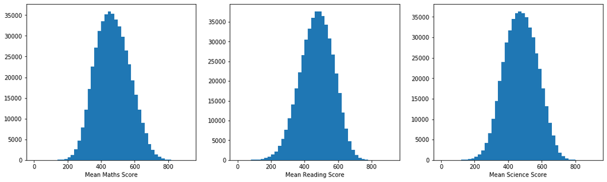

```python
# set plot size
plt.figure(figsize=[18,5])

# set bin edges the same for all three plots, as they have similar statistics -
# as found above
bin_edges = np.arange(0, 905+20, 20)

# plot the three mean scores using distplot (to help with inital bin sizes and
# provide option of KDE estimate)
plt.subplot(1,3,1)
sb.distplot(df.Mean_Maths_Score, bins = bin_edges, kde = False, hist_kws = {'alpha':1})
plt.xlabel('Mean Maths Score')

plt.subplot(1,3,2)
sb.distplot(df.Mean_Reading_Score, bins = bin_edges, kde = False, hist_kws = {'alpha':1})
plt.xlabel('Mean Reading Score')

plt.subplot(1,3,3)
sb.distplot(df.Mean_Science_Score, bins = bin_edges, kde = False, hist_kws = {'alpha':1})
plt.xlabel('Mean Science Score');
```

> The distributions of the three main score types are normally distributed. This would indicate the Pisa tests were of excellent technical quality, and the results of which are likely to be reliable indictors of student academic performance for each of the three subjects.

> I will need to identify any missing records to understand the completeness of the features I expect to use for the investigation.

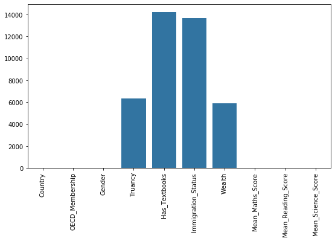

```python
# plot missing data using barplot
plt.figure(figsize=[9,5])
base_colour = sb.color_palette()[0]
na_counts = df.isna().sum()
sb.barplot(na_counts.index.values, na_counts, color = base_colour)
plt.xticks(rotation = 90);
```

> There absent records for four of the features I hope to use, however the number of missing records is small (between 1-3% of overall students) compared to the number of complete student records.

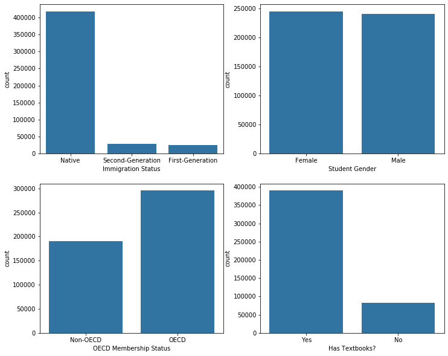

```python
# plot four of the categorical variables, using subplots

plt.figure(figsize=[12,10])

# check distribution of immigration status, sorted by frequency
plt.subplot(2,2,1)
cat_order = df.Immigration_Status.value_counts().index
sb.countplot(data=df, x='Immigration_Status', color=base_colour, order = cat_order)
plt.xlabel('Immigration Status')

# plot Gender split of students
plt.subplot(2,2,2)
sb.countplot(data=df, x='Gender', color=base_colour)
plt.xlabel('Student Gender')

# plot country count of OECD membership
plt.subplot(2,2,3)
sb.countplot(data=df, x='OECD_Membership', color=base_colour)
plt.xlabel('OECD Membership Status')

# plot number of students which have textbooks
plt.subplot(2,2,4)
sb.countplot(data=df, x='Has_Textbooks', color=base_colour)
plt.xlabel('Has Textbooks?');
```

> Immigration - predictably most students are native to their country of residence, with less than 30K students either first or second generation.

> Gender – There is an almost equal split of student gender (slightly higher count of female students), therefore no likely bias from the Pisa dataset and my results should also be free of gender bias.

> Moving on to the Truancy variable.

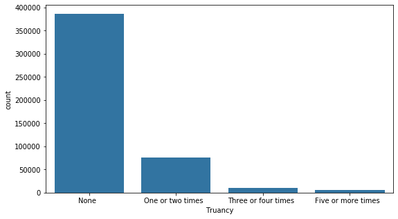

```python
# using countplot, plot frequencies for all values of Truancy feature
plt.figure(figsize = [9, 5])
sb.countplot(data = df, x='Truancy', color = base_colour)
plt.xlabel('Truancy');
```

> Almost 100k students have reported truancy to some extent, though most of one or two days. This available data should provide my investigation with a reasonable understanding of the effects of truancy on student scores.

> Now I will look at the distribution of the Wealth index variable.

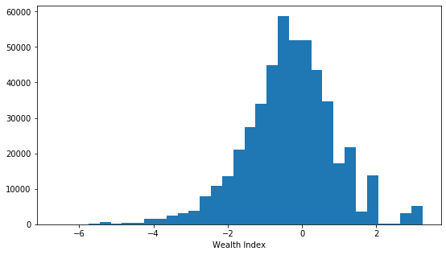

```python
# plot distribution of Wealth, using hist function
plt.figure(figsize=[9, 5])
bin_edges = np.arange(df['Wealth'].min(), df['Wealth'].max()+.3, .3)
plt.hist(data = df, x = 'Wealth', bins = bin_edges);
plt.xlabel('Wealth Index')
```

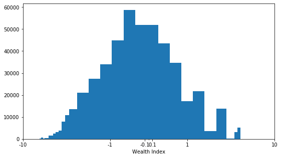

```python
# as there is a slightly long tail in the negative direction in the above distribution,
# check for a normal distribution using log scale. However, as there are negative values,
# set scale to a symmetic log scale to scale logarithmically to both sides of 0

plt.figure(figsize=[9, 5])
plt.hist(data = df, x = 'Wealth', bins = bin_edges)
plt.xscale('symlog')
tick_locs = [-10, -1, -.1, .1, 1, 10]
plt.xticks(tick_locs, tick_locs)
plt.xlabel('Wealth Index')
plt.show();
```

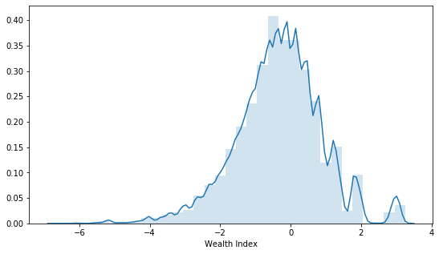

```python
# plot kernel density curve over histogram, to help to see how close to a
# normal distribution the Wealth index actually is
plt.figure(figsize=[9, 5])
sb.distplot(df.Wealth, bins = bin_edges, kde = True, hist_kws = {'alpha':.2})
plt.xlabel('Wealth Index');
```

```python
# using the .describe method, return basic statistical details of Wealth variable
df.Wealth.describe()
```

```
count    479597.00000
mean         -0.33701
std           1.21530
min          -6.65000
25%          -1.04000
50%          -0.30000
75%           0.43000
max           3.25000
Name: Wealth, dtype: float64
```

> Wealth appears to have a slightly long tail in the negative direction (though its marginal when compared to positive direction). To check, I used the symmetric log scale plot above, to find a slight normalisation of the distribution in the negative direction, though again only marginally when compared to the positive direction. I had another look at the original scale with a kernel density line, and think on balance using a standard scale is most suitable for the Wealth variable.

> The Wealth distribution, has several troughs (.75, 1.5, 2.5) and peaks (1, 1.75, 3), in the positive direction. The mean value is -0.3, and though the maximum is 3.25 and minimum is -6, the interquartile range is narrow between -1 and 0.4.

> A frequency count for the last variable of this section: Country

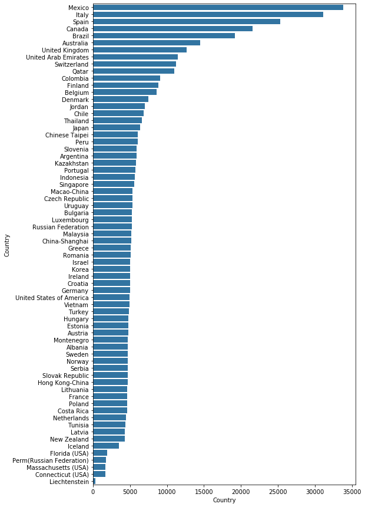

```python
# plot distribution of students for each country, sorted by frequency
plt.figure(figsize = [8, 15])
cat_order = df.Country.value_counts().index
sb.countplot(data=df, y='Country', color=base_colour, order = cat_order)
plt.xlabel('Country');
```

#### Variables of interest

> The three main scores are all very well 'normally' distributed and indicate the Pisa tests were of excellent technical quality, and the results are likely to be reliable indictors of student academic performance for each of the three subjects.

> The Wealth index, showed a slight skewing of the data in the negative direction, however after using a symmetric log transform, and considering the Kernel density curve in the standard scale, I decided on balance to use the standard scale for my investigation.

#### Unexpected distributions of features

> The unequal student counts per country were a surprise, however, I believe there are enough entries for each of the countries for my investigation.

## Bivariate Exploration

> To start, I will look at the pairwise plots and correlations of the numerical features of the data: Wealth and mean scores of mathematics, science and reading.

```python
# list of numerical variables
numeric_vars = ['Mean_Maths_Score', 'Mean_Reading_Score', 'Mean_Science_Score', 'Wealth']
```

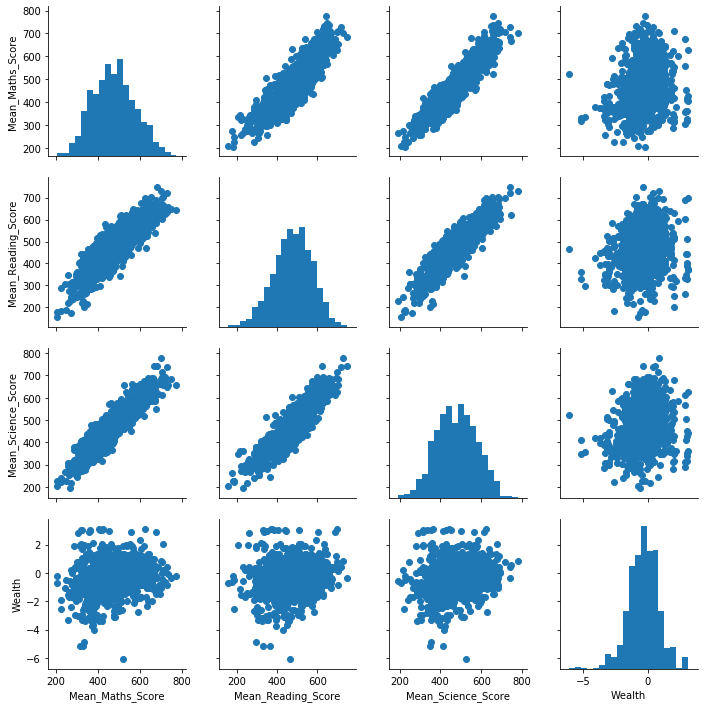

```python
# plot matrix: sample 1000 students so that plots are clearer and
# they render faster
samples = np.random.choice(df.shape[0], 1000, replace = False)
student_samp = df.loc[samples,:]

g = sb.PairGrid(data = student_samp, vars = numeric_vars)
g = g.map_diag(plt.hist, bins = 20)
g.map_offdiag(plt.scatter);
```

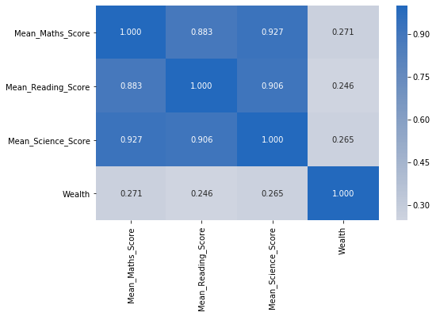

```python
# correlation plot
plt.figure(figsize = [8, 5])
sb.heatmap(df[numeric_vars].corr(), annot = True, fmt = '.3f',
           cmap = 'vlag_r', center = 0)
plt.show()
```

> As might be expected, we find a strong correlation between the three mean scores of mathematics, science and reading – if students perform well/or badly in one subject, they will likely have similar results in other subjects too.

> There is also a positive correlation between wealth and each of the mean score types, however not as pronounced as I might have expected. Reading is marginally less correlated to wealth than mathematics and science. This will require further exploration.

> Now moving onto how gender and the mean scores for each of the three subjects may be correlated.

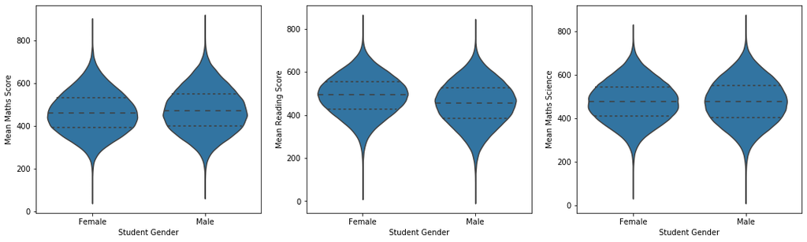

```python
# violin subplots - gender vs mean scores of Maths, Science and Reading

plt.figure(figsize=[18,5])

plt.subplot(1,3,1)
sb.violinplot(data=df, x='Gender', y='Mean_Maths_Score', color = base_colour, inner= 'quartile')
plt.xlabel('Student Gender')
plt.ylabel('Mean Maths Score')

plt.subplot(1,3,2)
sb.violinplot(data=df, x='Gender', y='Mean_Reading_Score', color = base_colour, inner= 'quartile')
plt.xlabel('Student Gender')
plt.ylabel('Mean Reading Score')

plt.subplot(1,3,3)
sb.violinplot(data=df, x='Gender', y='Mean_Science_Score', color = base_colour, inner= 'quartile')
plt.xlabel('Student Gender')
plt.ylabel('Mean Maths Science');
```

Kernel Density comparison between each gender, for each of the three mean score types

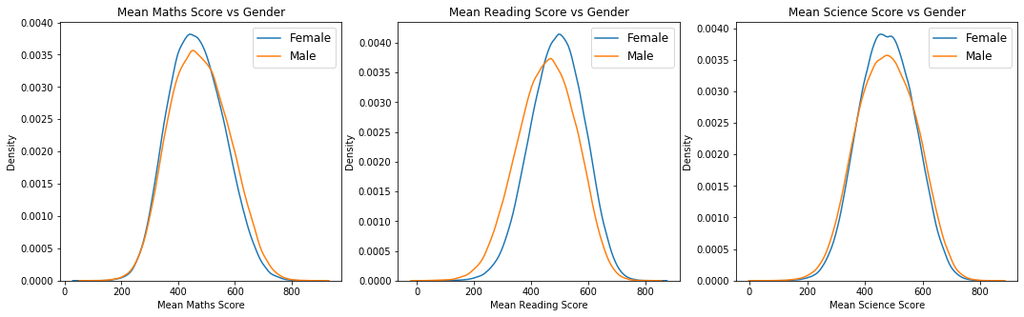

```python
# Overlaid Kernel density curves of distributions for each gender against the
# the three mean scores - Maths, Science and Reading
plt.figure(figsize=[18,5])

plt.subplot(1,3,1)
df1 = df[df.Gender == 'Female']
sb.distplot(df1['Mean_Maths_Score'], hist = False, kde = True,  label='Female')
df1 = df[df.Gender == 'Male']
sb.distplot(df1['Mean_Maths_Score'], hist = False, kde = True, label='Male')
# Plot formatting
plt.legend(prop={'size': 12})
plt.title('Mean Maths Score vs Gender')
plt.xlabel('Mean Maths Score')
plt.ylabel('Density')

plt.subplot(1,3,2)
df1 = df[df.Gender == 'Female']
sb.distplot(df1['Mean_Reading_Score'], hist = False, kde = True,  label='Female')
df1 = df[df.Gender == 'Male']
sb.distplot(df1['Mean_Reading_Score'], hist = False, kde = True, label='Male')
# formatting
plt.legend(prop={'size': 12})
plt.title('Mean Reading Score vs Gender')
plt.xlabel('Mean Reading Score')
plt.ylabel('Density')

plt.subplot(1,3,3)
df1 = df[df.Gender == 'Female']
sb.distplot(df1['Mean_Science_Score'], hist = False, kde = True,  label='Female')
df1 = df[df.Gender == 'Male']
sb.distplot(df1['Mean_Science_Score'], hist = False, kde = True, label='Male')
# formatting
plt.legend(prop={'size': 12})
plt.title('Mean Science Score vs Gender')
plt.xlabel('Mean Science Score')
plt.ylabel('Density');
```

> There some interesting correlations between gender and the three subject scores. Female students seem to do a lot better on the reading scores than male students, this is seen to be true across the whole range of data, as seen in the violin plots and KDE curves – where the female distribution curve is completely offset to higher score levels. Male students seem to do slightly better than female students in the upper band of scores in mathematics and science (though also slightly worse in the lower range of scores in science), however, female students are more likely to achieve average score across all three subjects – i.e. they have less variance across the scores.

> Next I want to see how having textbooks correlates with each score.

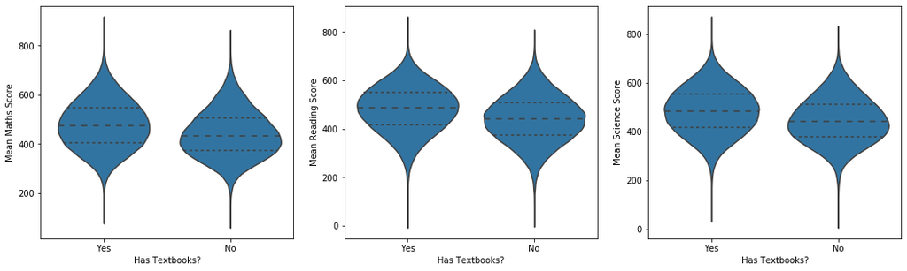

```python
# violin subplots - if students have textbooks vs mean scores of Maths, Science and Reading

plt.figure(figsize=[18,5])

plt.subplot(1,3,1)
sb.violinplot(data=df, x='Has_Textbooks', y='Mean_Maths_Score', color = base_colour, inner= 'quartile')
plt.xlabel('Has Textbooks?')
plt.ylabel('Mean Maths Score')

plt.subplot(1,3,2)
sb.violinplot(data=df, x='Has_Textbooks', y='Mean_Reading_Score', color = base_colour, inner= 'quartile')
plt.xlabel('Has Textbooks?')
plt.ylabel('Mean Reading Score')

plt.subplot(1,3,3)
sb.violinplot(data=df, x='Has_Textbooks', y='Mean_Science_Score', color = base_colour, inner= 'quartile')
plt.xlabel('Has Textbooks?')
plt.ylabel('Mean Science Score');
```

Kernel Density comparison of student textbook possession, for each of the three mean score types

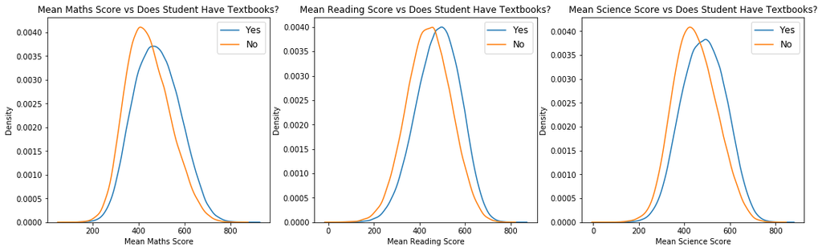

```python
# Overlaid Kernel density curves of distributions, of students possession of textbooks,
# for each of the three mean scores - Maths, Science and Reading

plt.figure(figsize=[18,5])

plt.subplot(1,3,1)
df1 = df[df.Has_Textbooks == 'Yes']
sb.distplot(df1['Mean_Maths_Score'], hist = False, kde = True,  label='Yes')
df1 = df[df.Has_Textbooks == 'No']
sb.distplot(df1['Mean_Maths_Score'], hist = False, kde = True, label='No')
# Plot formatting
plt.legend(prop={'size': 12})
plt.title('Mean Maths Score vs Does Student Have Textbooks?')
plt.xlabel('Mean Maths Score')
plt.ylabel('Density')

plt.subplot(1,3,2)
df1 = df[df.Has_Textbooks == 'Yes']
sb.distplot(df1['Mean_Reading_Score'], hist = False, kde = True,  label='Yes')
df1 = df[df.Has_Textbooks == 'No']
sb.distplot(df1['Mean_Reading_Score'], hist = False, kde = True, label='No')
# formatting
plt.legend(prop={'size': 12})
plt.title('Mean Reading Score vs Does Student Have Textbooks?')
plt.xlabel('Mean Reading Score')
plt.ylabel('Density')

plt.subplot(1,3,3)
df1 = df[df.Has_Textbooks == 'Yes']
sb.distplot(df1['Mean_Science_Score'], hist = False, kde = True,  label='Yes')
df1 = df[df.Has_Textbooks == 'No']
sb.distplot(df1['Mean_Science_Score'], hist = False, kde = True, label='No')
# formatting
plt.legend(prop={'size': 12})
plt.title('Mean Science Score vs Does Student Have Textbooks?')
plt.xlabel('Mean Science Score')
plt.ylabel('Density');
```

> There is no doubting the correlation between students having textbooks and the score they achieved in the study. Those students in possession of textbooks scored higher results for all three subjects. This affect is clearly seen in the mean and interquartile range of the violin plots and the large shift of all the Kerenel density curves.

> Next, I want to have a look at how the immigration status of a student maybe correlated to their scores.

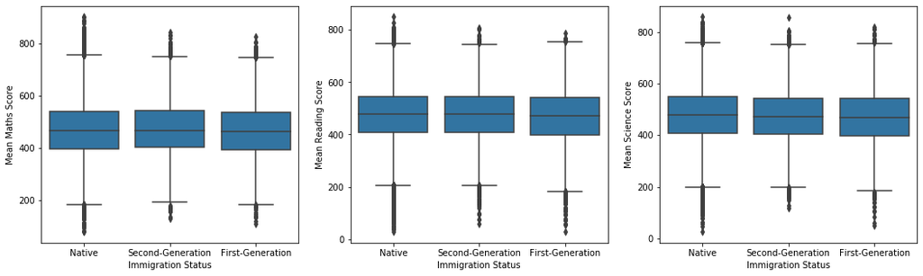

```python
# boxplot subplots, of immigration status vs mean scores - Maths, Science and Reading

plt.figure(figsize=[18,5])

plt.subplot(1,3,1)
sb.boxplot(data=df, x='Immigration_Status', y='Mean_Maths_Score', color = base_colour)
plt.xlabel('Immigration Status')
plt.ylabel('Mean Maths Score')

plt.subplot(1,3,2)
sb.boxplot(data=df, x='Immigration_Status', y='Mean_Reading_Score', color = base_colour)
plt.xlabel('Immigration Status')
plt.ylabel('Mean Reading Score')

plt.subplot(1,3,3)
sb.boxplot(data=df, x='Immigration_Status', y='Mean_Science_Score', color = base_colour)
plt.xlabel('Immigration Status')
plt.ylabel('Mean Science Score');
```

> As there doesn’t seem to be any meaningful correlation between the immigration status of the students in the study, and their scores for any of the three subjects, I won’t perform any further analyses with regard to immigration status for this investigation.

> Moving on, I want to now look at any possible correlation between a student’s country OECD membership status and mean scores.

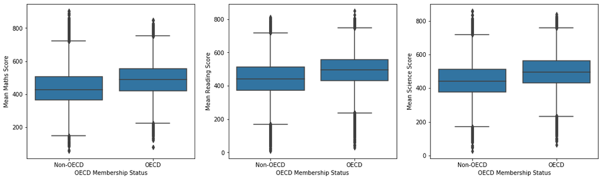

```python
# boxplot subplots of OECD country membership status vs mean scores - Maths, Science and Reading

plt.figure(figsize=[18,5])

plt.subplot(1,3,1)
sb.boxplot(data=df, x='OECD_Membership', y='Mean_Maths_Score', color = base_colour)
plt.xlabel('OECD Membership Status')
plt.ylabel('Mean Maths Score')

plt.subplot(1,3,2)
sb.boxplot(data=df, x='OECD_Membership', y='Mean_Reading_Score', color = base_colour)
plt.xlabel('OECD Membership Status')
plt.ylabel('Mean Reading Score')

plt.subplot(1,3,3)
sb.boxplot(data=df, x='OECD_Membership', y='Mean_Science_Score', color = base_colour)
plt.xlabel('OECD Membership Status')
plt.ylabel('Mean Science Score');
```

Kernel Density comparison between OECD membership status, for each of the three mean score types

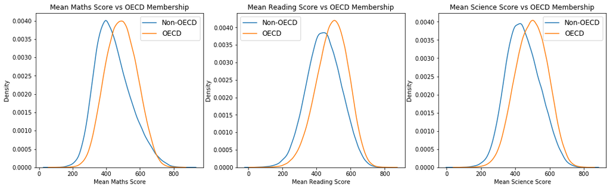

```python
# Overlaid Kernel density curves of distributions, for OECD membership status,
# for each of the three mean scores - Maths, Science and Reading

plt.figure(figsize=[18,5])

plt.subplot(1,3,1)
df1 = df[df.OECD_Membership == 'Non-OECD']
sb.distplot(df1['Mean_Maths_Score'], hist = False, kde = True,  label='Non-OECD')
df1 = df[df.OECD_Membership == 'OECD']
sb.distplot(df1['Mean_Maths_Score'], hist = False, kde = True, label='OECD')
# Plot formatting
plt.legend(prop={'size': 12})
plt.title('Mean Maths Score vs OECD Membership')
plt.xlabel('Mean Maths Score')
plt.ylabel('Density')

plt.subplot(1,3,2)
df1 = df[df.OECD_Membership == 'Non-OECD']
sb.distplot(df1['Mean_Reading_Score'], hist = False, kde = True,  label='Non-OECD')
df1 = df[df.OECD_Membership == 'OECD']
sb.distplot(df1['Mean_Reading_Score'], hist = False, kde = True, label='OECD')
# formatting
plt.legend(prop={'size': 12})
plt.title('Mean Reading Score vs OECD Membership')
plt.xlabel('Mean Reading Score')
plt.ylabel('Density')

plt.subplot(1,3,3)
df1 = df[df.OECD_Membership == 'Non-OECD']
sb.distplot(df1['Mean_Science_Score'], hist = False, kde = True,  label='Non-OECD')
df1 = df[df.OECD_Membership == 'OECD']
sb.distplot(df1['Mean_Science_Score'], hist = False, kde = True, label='OECD')
# formatting
plt.legend(prop={'size': 12})
plt.title('Mean Science Score vs OECD Membership')
plt.xlabel('Mean Science Score')
plt.ylabel('Density');
```

> There is a clear correlation between students of OECD member countries and their scores. Students of OECD member countries achieving much higher scores for each of the three main subjects. This is seen in the ranges depicted in the boxplots, and the complete shift of the KDE curves, with OECD member countries shifted to higher score levels.

> Now I want to look at what effect truancy plays in student’s scores, but before considering the score, I want to understand if there are any large differences between the genders and truancy.

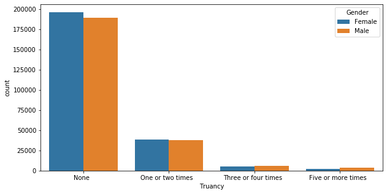

```python
# clustered bar chart depicting truancy counts of each value, for each gender

plt.figure(figsize = [10, 5])
sb.countplot(data=df, x= 'Truancy', hue = 'Gender')
plt.xlabel('Truancy');
```

> There is only a marginal difference between truancy levels between male and female students, and the effect appears too small to have any consequence for my investigation, and I will discount it moving forward.

> Next I will look to see if truancy is correlated to the student scores.

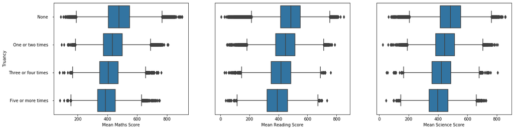

```python
# horizontal boxplot subplots of Truancy vs mean scores - Maths, Science and Reading
# using only single y axis label for all the plots
plt.figure(figsize=[20,5])

plt.subplot(1,3,1)
sb.boxplot(data=df, y='Truancy', x='Mean_Maths_Score', color = base_colour)
plt.ylabel('Truancy')
plt.xlabel('Mean Maths Score')

plt.subplot(1,3,2)
sb.boxplot(data=df, y='Truancy', x='Mean_Reading_Score', color = base_colour)
plt.ylabel('')
plt.yticks([])
plt.xlabel('Mean Reading Score')

plt.subplot(1,3,3)
sb.boxplot(data=df, y='Truancy', x='Mean_Science_Score', color = base_colour)
plt.ylabel('')
plt.yticks([])
plt.xlabel('Mean Science Score');
```

> There is no doubting how truancy effects a student’s score for each of the three subjects. A negative correlation can be seen here, with higher truancy leading clearly to lower scores.

> Now I will move on to look at how countries differ with regard to student scores for each of the three subjects.

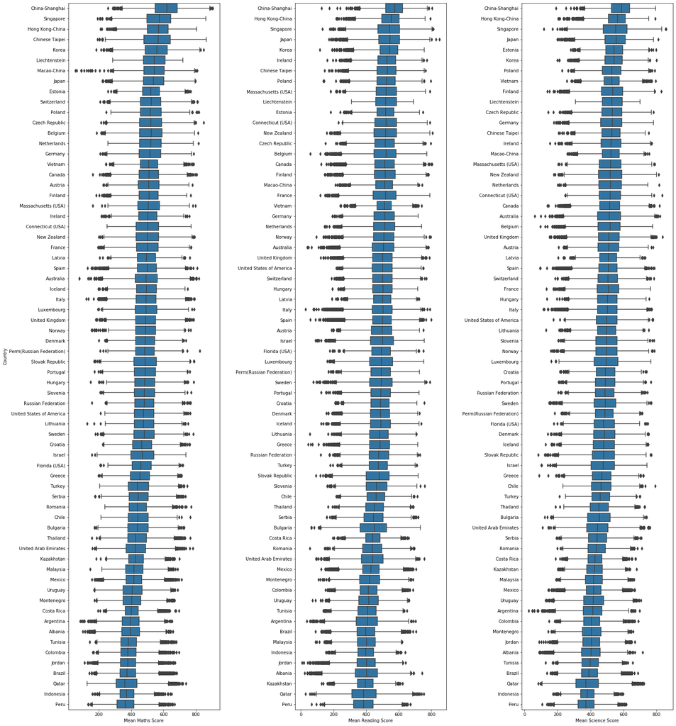

```python
# subplots of boxplots of each country vs the mean score values - maths, science and reading -
# sorted by frequency of mean scores for each country

# first set order of country mean scores - maths, science and reading
maths_order = df.groupby('Country')['Mean_Maths_Score'].mean().sort_values(ascending = False).index
reading_order = df.groupby('Country')['Mean_Reading_Score'].mean().sort_values(ascending = False).index
science_order = df.groupby('Country')['Mean_Science_Score'].mean().sort_values(ascending = False).index

plt.figure(figsize = [25, 30])
plt.subplots_adjust(wspace = 0.5)

plt.subplot(1,3,1)
sb.boxplot(data=df, x='Mean_Maths_Score', y='Country', color = base_colour, order = maths_order)
plt.ylabel('Country')
plt.xlabel('Mean Maths Score')

plt.subplot(1,3,2)
sb.boxplot(data=df, x='Mean_Reading_Score', y='Country', color = base_colour, order = reading_order)
plt.ylabel('')
plt.xlabel('Mean Reading Score')

plt.subplot(1,3,3)
sb.boxplot(data=df, x='Mean_Science_Score', y='Country',  color = base_colour, order = science_order)
plt.ylabel('')
plt.xlabel('Mean Science Score');
```

> We see from this data, students of some countries achieve much higher results than other countries. This result is interesting and want to analyse how wealth may play a part.

> To calculate the wealth of a country, I will first need group the mean wealth of all students for each country in the data, then plot the countries with regard to their respective wealth.

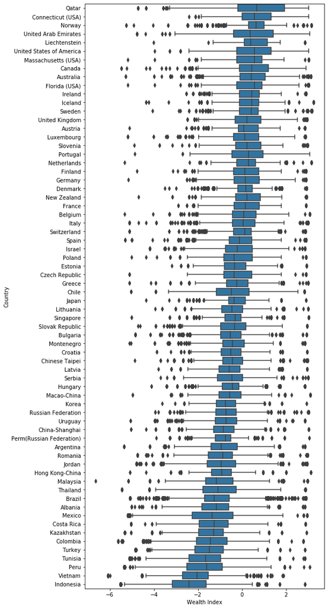

```python
# horizontal boxplot, of each country vs mean wealth index of residing students

plt.figure(figsize = [8, 20])
wealth_order = df.groupby('Country')['Wealth'].mean().sort_values(ascending = False).index
sb.boxplot(data=df, x='Wealth', y='Country', color = base_colour, order = wealth_order)
plt.ylabel('Country')
plt.xlabel('Wealth Index');
```

> We see from the above plot, there is a large difference in the relative wealth of countries, with Western and Middle Eastern countries largely proving to be more wealthy than Asian and South American countries.

> Now I want to pick up on an early finding, of the positively correlated effect wealth had on student scores for each of the three subjects, and to see this effect in greater detail by using regression lines to help with the analysis.

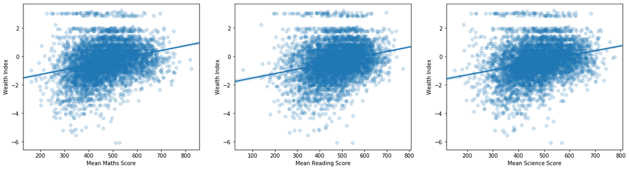

```python
# scatter plot (with regression line) of all three mean scores against wealth index,
# sampling 5000 students so that plots are clearer and they render faster

samples = np.random.choice(df.shape[0], 5000, replace = False)
student_samp = df.loc[samples,:]

plt.figure(figsize=[20,5])

plt.subplot(1,3,1)
sb.regplot(data=student_samp, x='Mean_Maths_Score', y='Wealth', scatter_kws = {'alpha':1/5})
plt.ylabel('Wealth Index')
plt.xlabel('Mean Maths Score')

plt.subplot(1,3,2)
sb.regplot(data=student_samp, x='Mean_Reading_Score', y='Wealth', scatter_kws = {'alpha':1/5})
plt.ylabel('Wealth Index')
plt.xlabel('Mean Reading Score')

plt.subplot(1,3,3)
sb.regplot(data=student_samp, x='Mean_Science_Score', y='Wealth', scatter_kws = {'alpha':1/5})
plt.ylabel('Wealth Index')
plt.xlabel('Mean Science Score');
```

> We see from the above three plots that there is indeed a clear positive correlation of wealth on student scores. As the three subjects largely exhibit near identical appearances in relation to distribution and correlations (seen by the regression lines) of wealth and student’s scores, I will focus on a single subject (mathematics) in large part for the rest for my investigation, where wealth and student scores are being considered.

> Now I want to see how the distribution of countries plot, with regard to wealth and the mean maths scores.

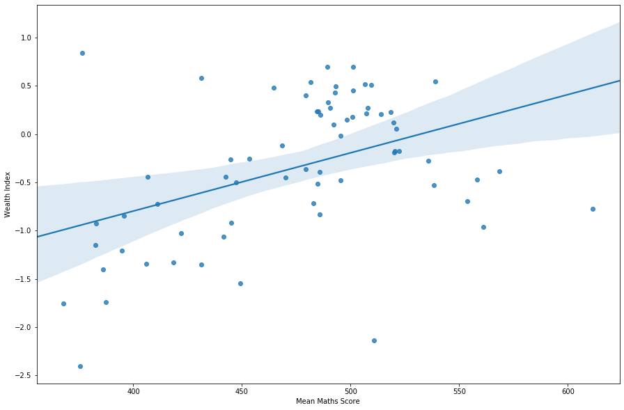

```python
# scatter plot (with regression line) to show distribution of country wealth against
# their mean maths score
plt.figure(figsize = [15, 10])
y = df.groupby('Country')['Wealth'].mean()
x = df.groupby('Country')['Mean_Maths_Score'].mean()
sb.regplot(data=df, x=x, y=y)
plt.ylabel('Wealth Index')
plt.xlabel('Mean Maths Score');
```

> This plot has some interesting features which standout straight away. Though in most part the scatter plot largely follows the expected trend, of a weak positive linear correlation betwen wealth and scores, there are some interesting outliers in this data which I want to investigate further.

> To understand the above plot, I will need to know which countries are falling not just outside the confidence interval for the regression estimate, but which countries are not even close to it.

> I will now annotate each plotted point with the appropriate country name, and also separate the plot into quadrants to highlight the areas both above and below the means for both the wealth and mean maths scores, to provide a reference to help to better understand the data.

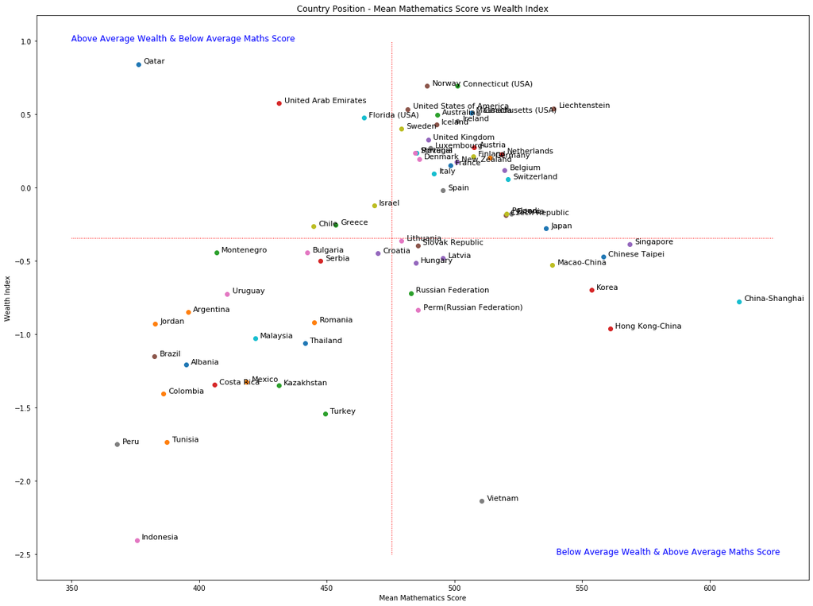

```python
# construct df of countries, grouped by their mean maths score and wealth
df_group = df.groupby('Country')['Mean_Maths_Score', 'Wealth'].mean()

fig, ax = plt.subplots()
fig.set_size_inches(20, 15)

# scatter plot of mean maths score vs mean wealth score for each country -
# annotating each point with the country name, using plt.text()
for i,country in enumerate(df_group.index):
    x= df_group.Mean_Maths_Score[i]
    y= df_group.Wealth[i]
    plt.scatter(x,y)
    plt.text(x+2, y+0.005, country, fontsize=11)

# add crosshairs to chart: overall mean maths score as a vertical line, and overall mean
# wealth index as a horizontal line
plt.plot([df_group['Mean_Maths_Score'].mean(),df_group['Mean_Maths_Score'].mean()],[-2.5,1],'r-',linestyle = ":",  lw=1)
plt.plot([350,625],[df_group['Wealth'].mean(),df_group['Wealth'].mean()],'r-', linestyle = ":", lw=1)

ax.set_title("Country Position - Mean Mathematics Score vs Wealth Index")
ax.set_xlabel("Mean Mathematics Score")
ax.set_ylabel("Wealth Index")

# add text to highlight quadrants where values fall in positions contrary to expectation
ax.text(350,1,"Above Average Wealth & Below Average Maths Score",color="blue",size="12")
ax.text(540,-2.5,"Below Average Wealth & Above Average Maths Score",color="blue",size="12")

plt.show();
```

> From this new re-worked scatter plot, we now find the countries at each data point. The most interesting positions are those countries that fall in the two quadrants highlighted above (above average wealth and below average maths scores, and below average wealth and above average maths scores), and in particular those countries which deviate most from the correlated values. Here we find one of the least wealthy countries Vietnam, whose students have above average maths scores. Hong Kong, China and Korea also follow the same trend of below average wealth and above average maths scores. Qatar on the other hand has the complete opposite effect, having the unenviable position of having one of the lowest average maths scores, though it is one of the wealthiest countries in the Pisa data.

### Relationships observed between main features of interest.

> As may be expected, there was found to be a very strong positive linear correlation between my main dependent variables of mean scores. In other words, if you did well in one of the subjects you were likely to do well in the other subjects too. A weak positive correlation was also found between wealth and score, though I needed to investigate this effect further.

> There some interesting correlations between gender and the three subject scores. Female students do a lot better on the reading scores than male students, this was seen to be true across the whole range of data. Male students seem to do slightly better than female students in the upper band of scores in mathematics and science (though also slightly worse in the lower range of scores in science), however, female students are more likely to achieve average score across all three subjects – i.e. they have less variance across the scores.

> Students having textbooks were highly correlated with higher scores for all three subjects. There is no doubting the improvement that textbooks made on scores.

> Immigration status did not seem to be correlated to the scores for any of the subjects, and I decided not to follow up on this enquiry for remainder of my investigation.

> A very strong correlation was found to exist between a country’s OECD membership and scores. OECD member countries had higher scores for all three subjects than non-members. This was interesting to me, as OECD member countries are understood to be richer$^{2}$ than non-members, and how a country’s wealth may affect student scores, was one of my main initial enquiries.

> Truancy was found to be negatively correlated with student scores, the higher the truancy level, the lower the student was likely to score across all of the three subjects.

### Other interesting observations.

> To investigate the weak positive correlation I had initially found between country wealth and scores, I decided to take the average student wealth for each country, and each country’s corresponding maths scores. Mapping each country to a plot, I found some very interesting outliers. Vietnam for example, one of the poorest countries was found to have above average maths scores, and Qatar, one of the wealthiest countries was actually found to have one of the lowest maths scores in the data!

## Multivariate Exploration

> In this part of my analysis, I want to explore how some of my main features may be correlated to each other and/or my dependent variables in unexpected ways.

> To start, I will look at the how OECD membership status maps to wealth and the maths scores, using a faceted heat map.

```python
# create heat maps with seaborn's PairGrid.
def hist2dgrid(x, y, **kwargs):
    palette = kwargs.pop('color')
    bins_x = np.arange(100, 900+10, 10)
    bins_y = np.arange(-7, 5+.3, 0.3)
    plt.hist2d(x, y, bins = [bins_x, bins_y], cmap = palette, cmin = 0.5)
```

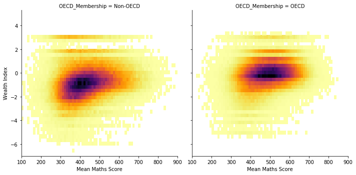

```python
# create faceted heat maps on country OECD status vs mean maths score and wealth,
# with results depicted horiztontally
g = sb.FacetGrid(data = df, col = 'OECD_Membership', col_wrap = 2, height = 5)

g.map(hist2dgrid, 'Mean_Maths_Score', 'Wealth', color = 'inferno_r')
g.set_xlabels('Mean Maths Score')
g.set_ylabels('Wealth Index')

plt.show()
```

> From the heatmap, we can see a strong correlation of OECD membership and wealth, which proves that on average OECD member countries are indeed richer than non-members. We also find the expected positive correlation between wealth/OECD membership and maths scores.

> We found earlier how gender had an effect on scores in the three subjects. Now I want to see if OECD membership also play a part.

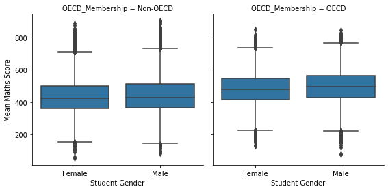

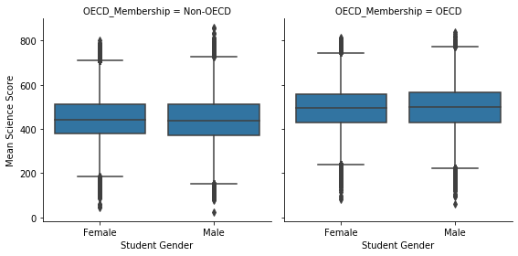

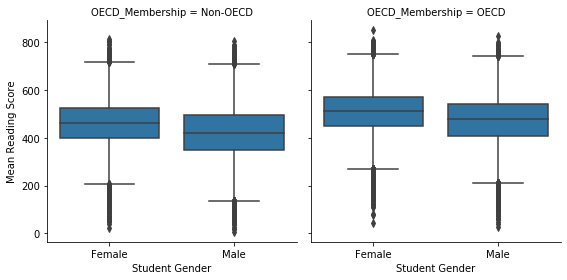

```python
# create FacetGrid plots of OECD country membership vs Gender, for of each of
# the three mean score types

g = sb.FacetGrid(data = df, col = 'OECD_Membership', height =4)
g.map(sb.boxplot, 'Gender', 'Mean_Maths_Score', color = base_colour)
g.set_xlabels('Student Gender')
g.set_ylabels('Mean Maths Score')

g = sb.FacetGrid(data = df, col = 'OECD_Membership', height =4)
g.map(sb.boxplot, 'Gender', 'Mean_Science_Score', color = base_colour)
g.set_xlabels('Student Gender')
g.set_ylabels('Mean Science Score')

g = sb.FacetGrid(data = df, col = 'OECD_Membership', height =4)
g.map(sb.boxplot, 'Gender', 'Mean_Reading_Score', color = base_colour)
g.set_xlabels('Student Gender')
g.set_ylabels('Mean Reading Score');
```

> We again find the correlation between scores and OCED membership, however here we also find male students benefit slightly more than female students from OECD membership, though the affect is marginal.

> Next, I want to see how truancy, though found to be correlated to maths scores, may also be affected by wealth too.

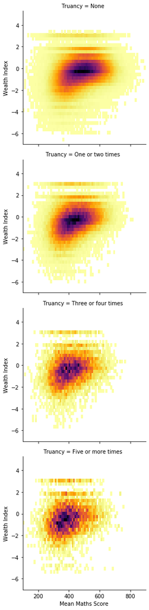

```python
# create faceted heat maps on levels of Truancy vs mean maths score and wealth,
 # with results stacked vertically
g = sb.FacetGrid(data = df, col = 'Truancy', col_wrap = 1, height = 4)

g.map(hist2dgrid, 'Mean_Maths_Score', 'Wealth', color = 'inferno_r')
g.set_xlabels('Mean Maths Score')
g.set_ylabels('Wealth Index')

plt.show()
```

> We find the expected correlation of truancy and maths scores as found previously, however it appears wealth does not seem to be correlated with truancy rates.

> We have seen how gender correlates differently for the three subjects, next I want to see how this affect maps out between the countries, and to see if there are certain countries the deviate from what was found previously.

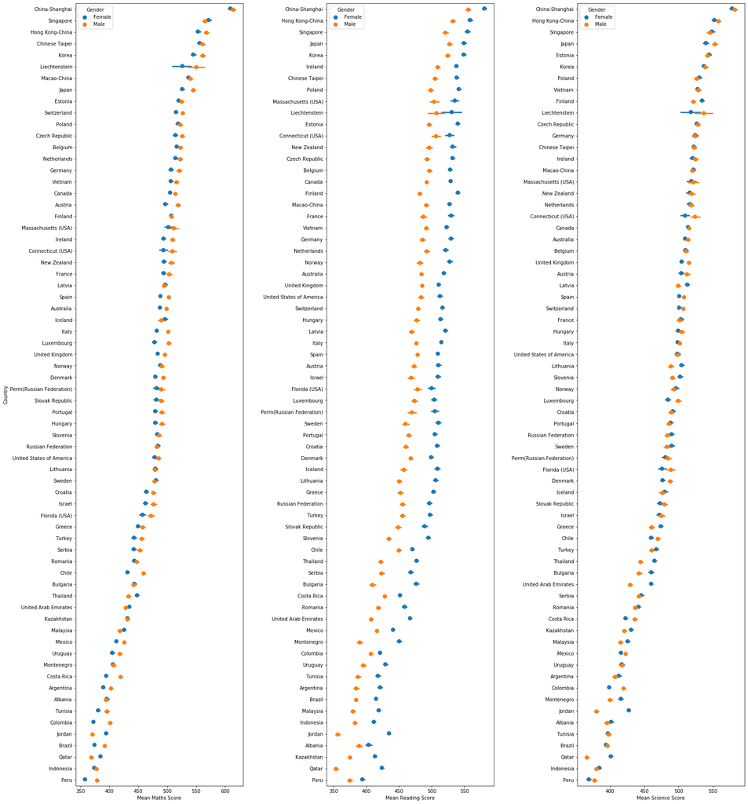

```python
# using pointplot subplots, plot each country against the mean score types, with gender in 'hue'
# parameter, to highlight differences of student gender for each country

plt.figure(figsize = [25, 30])
plt.subplots_adjust(wspace = 0.5)

plt.subplot(1,3,1)
ax = sb.pointplot(data = df, x= 'Mean_Maths_Score', y = 'Country', hue = 'Gender', dodge = 0.1,
                  linestyles = "", order = maths_order)
plt.ylabel('Country')
plt.xlabel('Mean Maths Score')

plt.subplot(1,3,2)
ax = sb.pointplot(data = df, x= 'Mean_Reading_Score', y = 'Country', hue = 'Gender', dodge = 0.1,
                  linestyles = "", order = reading_order)
plt.ylabel('')
plt.xlabel('Mean Reading Score')

plt.subplot(1,3,3)
ax = sb.pointplot(data = df, x= 'Mean_Science_Score', y = 'Country', hue = 'Gender', dodge = 0.1,
                  linestyles = "", order = science_order)
plt.ylabel('')
plt.xlabel('Mean Science Score');
```

> Jordan is found to have a greater number of female students which do better than male students not only in reading as expected, but also in mathematics and science too. United Arab Emirates, Thailand and Qatar also follow the same trend. However, it should be noted, that all these country scores are well below the average scores of mathematics and science. This result may also explain the result found earlier (from the facet grid of OECD vs gender and mean scores), that male students may benefit slightly more from OECD membership. A few non-member OECD countries maybe bringing down the male student average scores.